# Credit Card Fraud - Imbalanced Data Set

Winning kaggle notebook: https://www.kaggle.com/c/ieee-fraud-detection/discussion/111284 https://www.kaggle.com/cdeotte/xgb-fraud-with-magic-0-9600

**Use Case:** Credit Card Fraud Detection

```
Compare different common algorithms, develop and optimize a new 2 sequential/consecutive model algorithm to see if this can give better results
```

**Author:** Donald Stierman - Senior Data Scientist

**Details:** Imbalanced data can cause issues with most Machine Learning Algorithms and Neural Networks. To alleviate this, I choose to down-sample the training data to use as the input dataset. After creating the down-sampled dataset, I ran this through several different common model algorithms, including a new modeling technique I developed specifically for imbalanced data. I got this idea after reading about some highly effective Healthcare screening solutions currently in use. I.E. Breast Cancer detection in women (see comments: below). If a mammogram comes back positive, we already know that there will be a lot of false positives (benign tumors, scars, etc). Usually the doctor will follow up with a 2nd test, such as biopsy. This will screen out the false positives leaving mostly true positives (cancerous tissue). This same idea can possibly be applied to credit care fraud. We want to catch all true cases of fraud (fraud prevention), to be compliant with government regulations, and additionally not create a huge workload of false cases to be investigated (cost control).

comments:

**Here are some different ways to explain the methodology used in the Healthcare use case:**

*1st test (high specificity) -> 2nd test (high sensitivity) -> Only treat cancerous tissue

*TN/(TN + FP) is high ~ 1 -> TP/(TP + FN) is high ~ 1 -> Find all Positive cases

*catch all possible cases/remove healthy patients -> remove all false flags -> high confidence in Positive result/few missed positives

This same methodology can be applied to Credit Card Fraud detection

Link to code repo at Github:

https://github.com/donaldstierman/imbalanced_data

**Models used:**

```
    Logistic Regression
    Random Forest
    Gradient Boosted Decision Trees
    Customized 2 Step Gradient Boosted Decision Trees
    Deep Neural Network
    1D Convolutional Neural Network
    AutoEncoder
```

**Goal:** For this example, I chose 2 metrics to optimize, ROC/AUC and best "macro avg recall". I chose these because in the health care example, it is better to catch all cancer patients, even if it means more tests are performed. To compare the results, first objective is to find the best overall model (lowest mislabelled predictions), second is to find the model that has a low number of false negatives (faudulent transactions that are missed) without having too many false positives (genuine transactions that are needlessly investigated)

```
    1) Compare the AUC to find the most robust model of the single step models. However, the value of this metric cannot be calculated directly on the 2 step model, so we need to use #2 below for final comparison
    2) Maximize the Sensitivity (higher priority) or reduce the number of False Negatives (FN/TP ratio) and maximize the Specificity (lower priority) to control the number of tests performed in the 2nd step. I.E. catch all the fraudulent transaction even if there are false flags (false positives).
```

[output not shown]

```
no display found. Using non-interactive Agg backend
```

Always like to include a timer function to see where my code is running slow or taking most of the run time

Setup to run on Google Colab and Kaggle platforms

```
Current Working Directory  C:\DataScience\Repo\Imbalanced_data\CreditCardFraud\input\creditcardzip
```

Public Credit Card Dataset. This is financial data, and is considered to be sensitive so it is "encrypted" through the use of PCA to protect privacy. Only the Time and Dollar columns are intact after the "encryption"

Doing some initial data exploration

```
   Time        V1        V2        V3        V4        V5        V6        V7  \
0   0.0 -1.359807 -0.072781  2.536347  1.378155 -0.338321  0.462388  0.239599
1   0.0  1.191857  0.266151  0.166480  0.448154  0.060018 -0.082361 -0.078803
2   1.0 -1.358354 -1.340163  1.773209  0.379780 -0.503198  1.800499  0.791461
3   1.0 -0.966272 -0.185226  1.792993 -0.863291 -0.010309  1.247203  0.237609
4   2.0 -1.158233  0.877737  1.548718  0.403034 -0.407193  0.095921  0.592941

         V8        V9  ...       V21       V22       V23       V24       V25  \
0  0.098698  0.363787  ... -0.018307  0.277838 -0.110474  0.066928  0.128539
1  0.085102 -0.255425  ... -0.225775 -0.638672  0.101288 -0.339846  0.167170
2  0.247676 -1.514654  ...  0.247998  0.771679  0.909412 -0.689281 -0.327642
3  0.377436 -1.387024  ... -0.108300  0.005274 -0.190321 -1.175575  0.647376
4 -0.270533  0.817739  ... -0.009431  0.798278 -0.137458  0.141267 -0.206010

        V26       V27       V28  Amount  Class
0 -0.189115  0.133558 -0.021053  149.62      0
1  0.125895 -0.008983  0.014724    2.69      0
2 -0.139097 -0.055353 -0.059752  378.66      0
3 -0.221929  0.062723  0.061458  123.50      0
4  0.502292  0.219422  0.215153   69.99      0

[5 rows x 31 columns]
```

```
<class 'pandas.core.frame.DataFrame'>
RangeIndex: 284807 entries, 0 to 284806
Data columns (total 31 columns):
 #   Column  Non-Null Count   Dtype
---  ------  --------------   -----
 0   Time    284807 non-null  float64
 1   V1      284807 non-null  float64
 2   V2      284807 non-null  float64
 3   V3      284807 non-null  float64
 4   V4      284807 non-null  float64
 5   V5      284807 non-null  float64
 6   V6      284807 non-null  float64
 7   V7      284807 non-null  float64
 8   V8      284807 non-null  float64
 9   V9      284807 non-null  float64
```

[output cut: 23 more lines]

```
Time      124592
V1        275663
V2        275663
V3        275663
V4        275663
V5        275663
V6        275663
V7        275663
V8        275663
V9        275663
V10       275663
V11       275663
V12       275663
V13       275663
V14       275663
V15       275663
V16       275663
V17       275663
V18       275663
V19       275663
V20       275663
V21       275663
V22       275663
V23       275663
V24       275663
V25       275663
V26       275663
V27       275663
V28       275663
Amount     32767
Class          2
dtype: int64
```

```
Time      0
V1        0
V2        0
V3        0
V4        0
V5        0
V6        0
V7        0
V8        0
V9        0
V10       0
V11       0
V12       0
V13       0
V14       0
V15       0
V16       0
V17       0
V18       0
V19       0
V20       0
V21       0
V22       0
V23       0
V24       0
V25       0
V26       0
V27       0
V28       0
Amount    0
Class     0
dtype: int64
```

|  | Time | V1 | V2 | V3 | V4 | V5 | V6 | V7 | V8 | V9 | ... | V21 | V22 | V23 | V24 | V25 | V26 | V27 | V28 | Amount | Class |
| --- | --- | --- | --- | --- | --- | --- | --- | --- | --- | --- | --- | --- | --- | --- | --- | --- | --- | --- | --- | --- | --- |
| count | 284807.000000 | 2.848070e+05 | 2.848070e+05 | 2.848070e+05 | 2.848070e+05 | 2.848070e+05 | 2.848070e+05 | 2.848070e+05 | 2.848070e+05 | 2.848070e+05 | ... | 2.848070e+05 | 2.848070e+05 | 2.848070e+05 | 2.848070e+05 | 2.848070e+05 | 2.848070e+05 | 2.848070e+05 | 2.848070e+05 | 284807.000000 | 284807.000000 |
| mean | 94813.859575 | 1.165980e-15 | 3.416908e-16 | -1.373150e-15 | 2.086869e-15 | 9.604066e-16 | 1.490107e-15 | -5.556467e-16 | 1.177556e-16 | -2.406455e-15 | ... | 1.656562e-16 | -3.444850e-16 | 2.578648e-16 | 4.471968e-15 | 5.340915e-16 | 1.687098e-15 | -3.666453e-16 | -1.220404e-16 | 88.349619 | 0.001727 |
| std | 47488.145955 | 1.958696e+00 | 1.651309e+00 | 1.516255e+00 | 1.415869e+00 | 1.380247e+00 | 1.332271e+00 | 1.237094e+00 | 1.194353e+00 | 1.098632e+00 | ... | 7.345240e-01 | 7.257016e-01 | 6.244603e-01 | 6.056471e-01 | 5.212781e-01 | 4.822270e-01 | 4.036325e-01 | 3.300833e-01 | 250.120109 | 0.041527 |
| min | 0.000000 | -5.640751e+01 | -7.271573e+01 | -4.832559e+01 | -5.683171e+00 | -1.137433e+02 | -2.616051e+01 | -4.355724e+01 | -7.321672e+01 | -1.343407e+01 | ... | -3.483038e+01 | -1.093314e+01 | -4.480774e+01 | -2.836627e+00 | -1.029540e+01 | -2.604551e+00 | -2.256568e+01 | -1.543008e+01 | 0.000000 | 0.000000 |
| 25% | 54201.500000 | -9.203734e-01 | -5.985499e-01 | -8.903648e-01 | -8.486401e-01 | -6.915971e-01 | -7.682956e-01 | -5.540759e-01 | -2.086297e-01 | -6.430976e-01 | ... | -2.283949e-01 | -5.423504e-01 | -1.618463e-01 | -3.545861e-01 | -3.171451e-01 | -3.269839e-01 | -7.083953e-02 | -5.295979e-02 | 5.600000 | 0.000000 |
| 50% | 84692.000000 | 1.810880e-02 | 6.548556e-02 | 1.798463e-01 | -1.984653e-02 | -5.433583e-02 | -2.741871e-01 | 4.010308e-02 | 2.235804e-02 | -5.142873e-02 | ... | -2.945017e-02 | 6.781943e-03 | -1.119293e-02 | 4.097606e-02 | 1.659350e-02 | -5.213911e-02 | 1.342146e-03 | 1.124383e-02 | 22.000000 | 0.000000 |
| 75% | 139320.500000 | 1.315642e+00 | 8.037239e-01 | 1.027196e+00 | 7.433413e-01 | 6.119264e-01 | 3.985649e-01 | 5.704361e-01 | 3.273459e-01 | 5.971390e-01 | ... | 1.863772e-01 | 5.285536e-01 | 1.476421e-01 | 4.395266e-01 | 3.507156e-01 | 2.409522e-01 | 9.104512e-02 | 7.827995e-02 | 77.165000 | 0.000000 |
| max | 172792.000000 | 2.454930e+00 | 2.205773e+01 | 9.382558e+00 | 1.687534e+01 | 3.480167e+01 | 7.330163e+01 | 1.205895e+02 | 2.000721e+01 | 1.559499e+01 | ... | 2.720284e+01 | 1.050309e+01 | 2.252841e+01 | 4.584549e+00 | 7.519589e+00 | 3.517346e+00 | 3.161220e+01 | 3.384781e+01 | 25691.160000 | 1.000000 |

8 rows × 31 columns

```
0    284315
1       492
Name: Class, dtype: int64
```

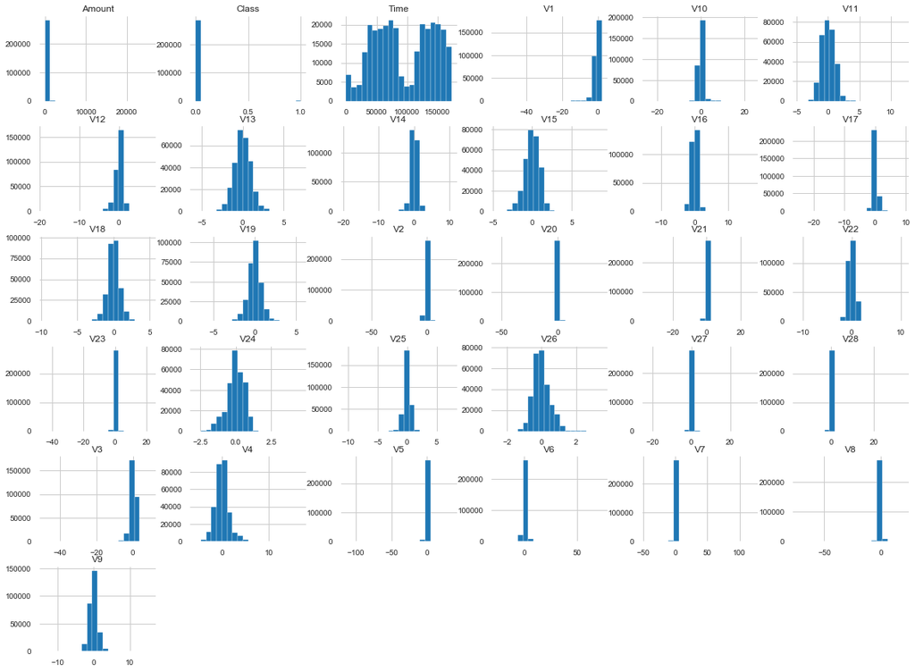

Look at cross correlations between features. Most models will be fine with collinearity, but good to know this in any case. Most of my input is numerical, and my label is binary classification, so I can choose the Anova or Kendall's method. I will try the Kendall tau-b method first. This method will sort the 2 columns and compare if the X is always > or < Y. If so, the tau-b value will be 1.

Some key points to remember: Kendall’s Tau: Calculations based on concordant and discordant pairs. Insensitive to error. P values are more accurate with smaller sample sizes. Good resource can be found here: https://online.stat.psu.edu/stat509/node/158/

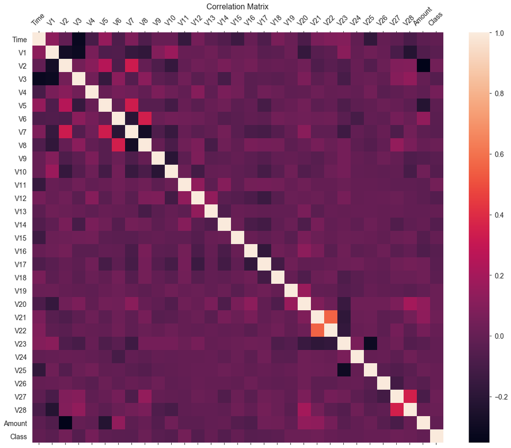

V21 and V22 show the highest tau-b score, will investigate this relationship later

Divide the dataset into features and labels and then into Train, Test and Validate datasets

```
Original
[[     0      1]
 [284315    492]]
```

```
Train
[[     0      1]
 [199020    344]]
Train
[[    0     1]
 [59709   101]]
Train
[[    0     1]
 [25586    47]]
```

Investigate the high tau-b value between V21 and V22

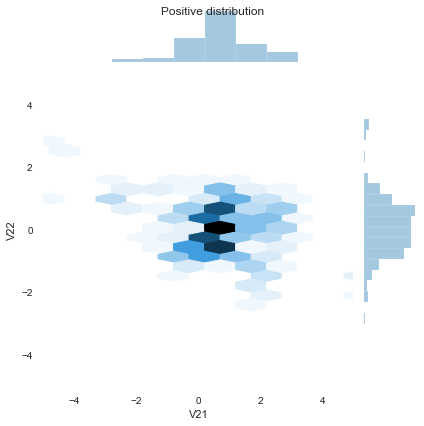

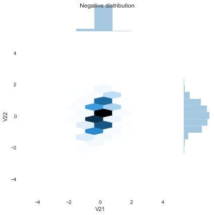

V21 shows a slight one-sided tail, however Kendall's correlation test is good to use here as it is a non-parametric test and can handle non-gaussian distributions like this

For a imbalanced sampling strategy, I will be using undersampling in my project as i think this is the best approach for this type of data

Create some calculation and visualization functions to show the results

|  | V1 | V2 | V3 | V4 | V5 | V6 | V7 | V8 | V9 | V10 | ... | V20 | V21 | V22 | V23 | V24 | V25 | V26 | V27 | V28 | Log_Amount |
| --- | --- | --- | --- | --- | --- | --- | --- | --- | --- | --- | --- | --- | --- | --- | --- | --- | --- | --- | --- | --- | --- |
| 198603 | 2.127494 | -0.042208 | -1.530728 | 0.122169 | 0.525801 | -0.353298 | 0.141751 | -0.217101 | 0.509423 | 0.053538 | ... | -0.141266 | -0.339534 | -0.855285 | 0.278614 | 0.043430 | -0.163358 | 0.206728 | -0.073466 | -0.059643 | -0.115411 |
| 250681 | 1.888725 | -0.153855 | -1.877025 | 0.202953 | 1.129556 | 1.154050 | -0.242036 | 0.443075 | 0.685173 | -0.530143 | ... | -0.375330 | -0.263361 | -0.570365 | 0.475884 | -0.902981 | -0.612022 | 0.307979 | -0.000442 | -0.048449 | 1.095608 |
| 157279 | 2.189227 | -0.209435 | -2.209515 | -1.425581 | 0.623486 | -1.209318 | 0.503029 | -0.659253 | 2.643368 | -1.285127 | ... | -0.120127 | -0.194757 | 0.040196 | -0.139224 | -0.962725 | 0.542623 | -0.113327 | -0.061684 | -0.083817 | 3.124609 |
| 46829 | -0.427746 | 0.665115 | 1.994781 | 0.021003 | -0.203040 | 0.337650 | 0.094800 | 0.118950 | 0.338687 | -0.606753 | ... | 0.013299 | -0.043506 | 0.031770 | -0.234859 | -0.403868 | -0.084152 | 0.312323 | -0.059667 | 0.057509 | 2.442434 |
| 238297 | -0.993763 | 0.370382 | 0.231293 | 0.105992 | 0.653732 | -1.047925 | 0.133278 | 0.359363 | -0.755932 | -0.516728 | ... | 0.073013 | 0.516833 | 1.196490 | -0.334644 | 0.071169 | -0.051329 | 0.015480 | 0.049673 | -0.030817 | 0.001000 |
| ... | ... | ... | ... | ... | ... | ... | ... | ... | ... | ... | ... | ... | ... | ... | ... | ... | ... | ... | ... | ... | ... |
| 153823 | -19.641857 | 14.706335 | -22.801238 | 12.114672 | -14.898113 | 0.840778 | -28.011293 | -11.919639 | -8.960922 | -18.913243 | ... | 3.834649 | -8.228874 | 3.318178 | 2.585212 | 0.195009 | -1.194803 | 0.038423 | -4.126746 | -0.645329 | 0.824614 |
| 147605 | 1.917827 | 0.951967 | -2.059206 | 3.833998 | 1.668192 | 0.769826 | 0.232463 | 0.107941 | -1.143646 | 0.541699 | ... | -0.115922 | 0.015255 | 0.239994 | -0.111916 | -0.380576 | 0.370995 | 0.189117 | -0.005823 | -0.012105 | 2.220398 |
| 119714 | -0.734303 | 0.435519 | -0.530866 | -0.471120 | 0.643214 | 0.713832 | -1.234572 | -2.551412 | -2.057724 | 0.166831 | ... | 0.864536 | -1.004877 | 1.150354 | -0.152555 | -1.386745 | 0.004716 | 0.219146 | -0.058257 | 0.158048 | 3.399563 |
| 11880 | -15.819179 | 8.775997 | -22.804686 | 11.864868 | -9.092361 | -2.386893 | -16.560368 | 0.948349 | -6.310658 | -13.088891 | ... | 0.992279 | -2.350634 | 1.036362 | 1.136051 | -1.043414 | -0.108923 | 0.657437 | 2.136424 | -1.411945 | 0.001000 |
| 144108 | -3.586964 | 2.609127 | -5.568577 | 3.631947 | -4.543590 | -0.157899 | -4.089128 | 2.417305 | -3.239901 | -5.822449 | ... | -0.178534 | 1.024423 | 0.428756 | 0.182032 | -0.534598 | 0.168933 | -0.149844 | 0.685517 | -0.299728 | 5.737929 |

688 rows × 29 columns

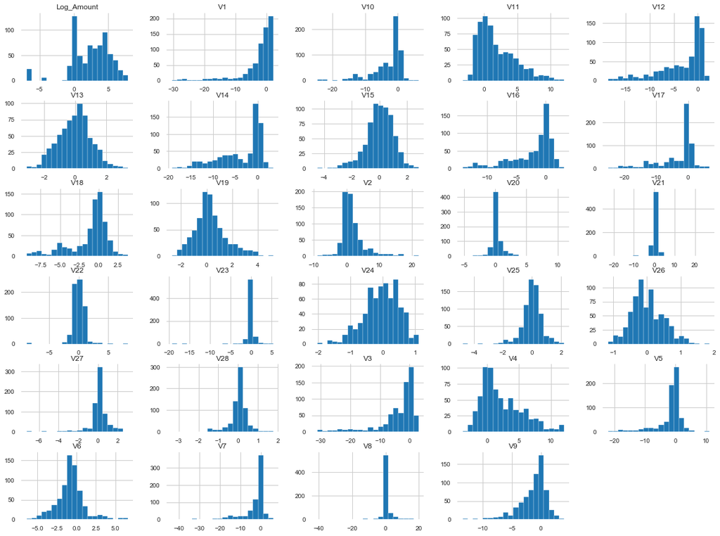

run Logistic Regression model first

Show the results of this model

```
0.959839491723792
0.959839491723792
Accuracy score (training): 0.961
Accuracy score (validation): 0.960
error
Confusion Matrix:
false positive pct: 3.9976592543053004
tn  fp  fn  tp
57318 2391 11 90
[[57318  2391]
 [   11    90]]
Classification Report
              precision    recall  f1-score   support

           0       1.00      0.96      0.98     59709
           1       0.04      0.89      0.07       101

    accuracy                           0.96     59810
   macro avg       0.52      0.93      0.52     59810
weighted avg       1.00      0.96      0.98     59810

Specificity = 0.9599557855599659
Sensitivity = 0.8910891089108911
LR:TEST | AUC Score: 0.974
```

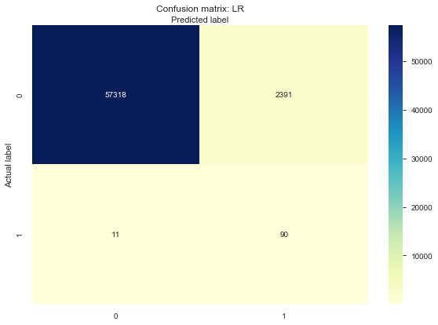

```
  No Skill : ROC AUC=0.500
        LR : ROC AUC=0.974
```

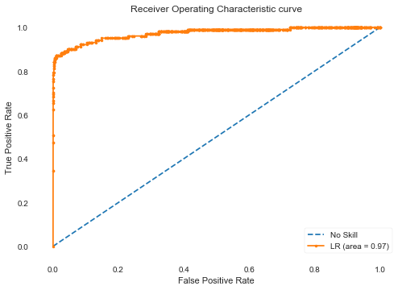

```
Logistic: f1=0.070 auc=0.464
```

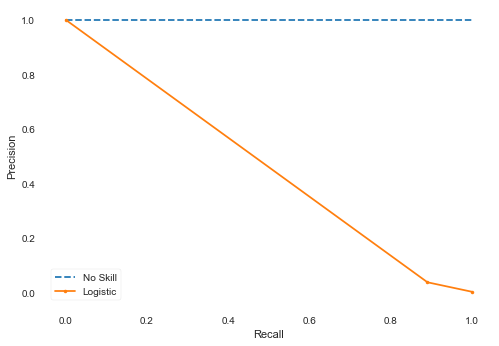

Next try the Random Forest model

Show the results of this model

```
              precision    recall  f1-score   support

           0       1.00      0.98      0.99     59709
           1       0.08      0.86      0.15       101

    accuracy                           0.98     59810
   macro avg       0.54      0.92      0.57     59810
weighted avg       1.00      0.98      0.99     59810

0.9836816585855208
Accuracy score (training): 1.000
Accuracy score (validation): 0.984
AxesSubplot(0.125,0.125;0.775x0.755)
Confusion Matrix:
false positive pct: 1.6084266845009194
tn  fp  fn  tp
58747 962 14 87
[[58747   962]
 [   14    87]]
Classification Report
              precision    recall  f1-score   support

           0       1.00      0.98      0.99     59709
           1       0.08      0.86      0.15       101

    accuracy                           0.98     59810
   macro avg       0.54      0.92      0.57     59810
weighted avg       1.00      0.98      0.99     59810

Specificity = 0.9838885260178533
Sensitivity = 0.8613861386138614
RF:TEST | AUC Score: 0.973
```

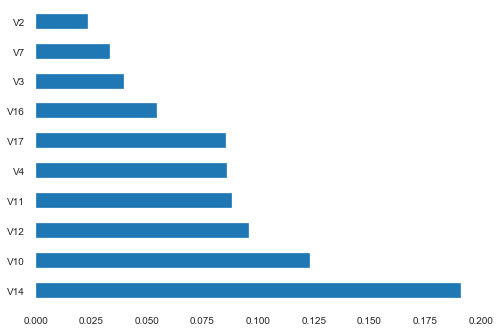

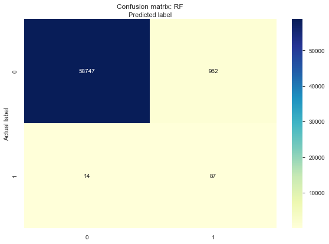

```
  No Skill : ROC AUC=0.500
        RF : ROC AUC=0.973
```

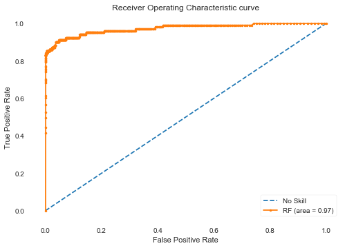

Now lets try a GradientBoosting Algorithm

Display the results

```
0.9833305467313158
Accuracy score (training): 0.942
Accuracy score (validation): 0.983
AxesSubplot(0.125,0.125;0.775x0.755)
Confusion Matrix:
false positive pct: 1.6435378699214176
tn  fp  fn  tp
58726 983 14 87
[[58726   983]
 [   14    87]]
Classification Report
              precision    recall  f1-score   support

           0       1.00      0.98      0.99     59709
           1       0.08      0.86      0.15       101

    accuracy                           0.98     59810
   macro avg       0.54      0.92      0.57     59810
weighted avg       1.00      0.98      0.99     59810

Specificity = 0.9835368202448542
Sensitivity = 0.8613861386138614
GB:TEST | AUC Score: 0.951
```

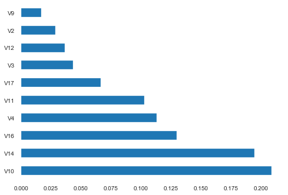

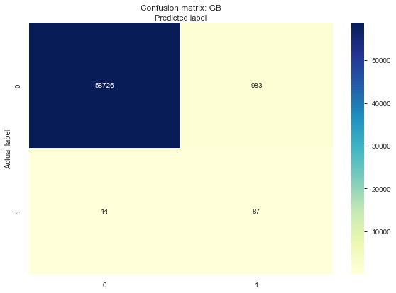

```
  No Skill : ROC AUC=0.500
        GB : ROC AUC=0.951
```

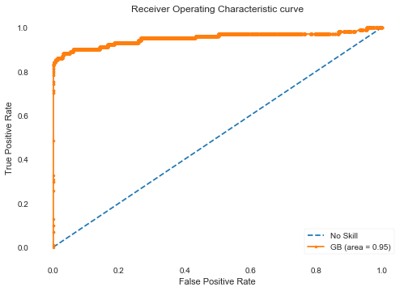

My next idea is to run 2 consecutive models consecutively. 1st model should have low false negatives to catch (almost) all the actual positives, even if the number of false positives is high. Then only take these records with a predicted 1 value (should only be a few thousand), as the input for the next model. 2nd test should have low false positives to weed out the actual negatives. Will use the Validate dataset on the 2 models created from the Train and Test datasets

Here are some details on the new model:

Current: Full Dataset -> Train -> Build M1(Train) -> Run M1(Test) -> Filter(Predicted 1's from Test) -> Build M2 -> run M2(Filtered Test) Test

To Do:  
Full Dataset -> Train -> Build M1(Train) -> Run M1(Test) -> Filter(Predicted 1's from Test) -> Build M2 -> run M1 and M2(Validate) Test Validate

Can also try the inverse, but think that option will have less chance of success.

1st step

build the 1st model to be used later on the validate dataset

```
0.9425012539709079
Accuracy score (training): 0.965
Accuracy score (validation): 0.943
AxesSubplot(0.125,0.125;0.775x0.755)
Confusion Matrix:
false positive pct: 5.731483029593713
tn  fp  fn  tp
56281 3428 11 90
[[56281  3428]
 [   11    90]]
Classification Report
              precision    recall  f1-score   support

           0       1.00      0.94      0.97     59709
           1       0.03      0.89      0.05       101

    accuracy                           0.94     59810
   macro avg       0.51      0.92      0.51     59810
weighted avg       1.00      0.94      0.97     59810

Specificity = 0.9425882195313939
Sensitivity = 0.8910891089108911
GB1 Train **:TEST | AUC Score: 0.97
```

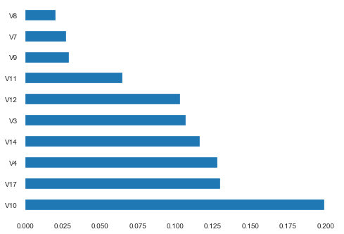

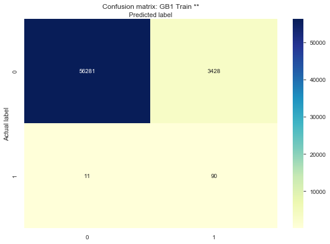

```
  No Skill : ROC AUC=0.500
GB1 Train ** : ROC AUC=0.970
```

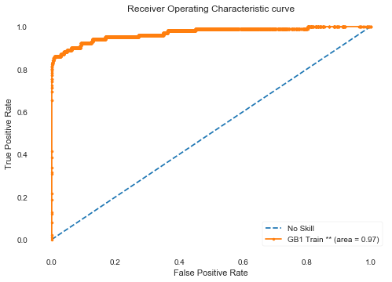

Add 1st model prediction column to X_test for filtering

select rows with prediction of 1

Create 2nd train dataset from 1st dataset where the prediction was 1

|  | Class |
| --- | --- |
| 10217 | 0 |
| 115511 | 0 |
| 149403 | 0 |
| 243932 | 0 |
| 146700 | 0 |
| ... | ... |
| 81618 | 0 |
| 80740 | 0 |
| 75422 | 0 |
| 153933 | 0 |
| 240251 | 0 |

59810 rows × 1 columns

clean up the X_test dataset for future modeling, means remove the Prediction column

Look at the prediction values from the first model (preda_1) for the rows with a predicted label of 0

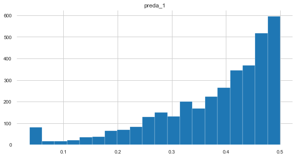

Then we look at the ROC curve

```
  No Skill : ROC AUC=0.500
PredictedPositives : ROC AUC=0.971
```

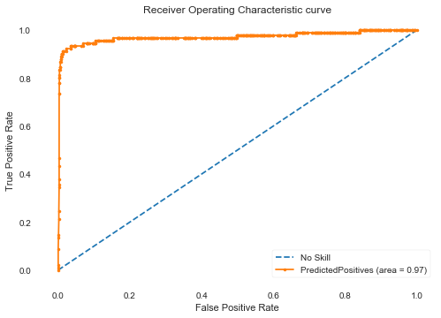

```
0.971
```

Next we build the 2nd model to be used model later on the validate dataset and look at the output

```
0.28425241614553726
Accuracy score (training): 0.969
Accuracy score (validation): 0.284
AxesSubplot(0.125,0.125;0.775x0.755)
Confusion Matrix:
false positive pct: 71.54633314383172
tn  fp  fn  tp
911 2517 1 89
[[ 911 2517]
 [   1   89]]
Classification Report
              precision    recall  f1-score   support

           0       1.00      0.27      0.42      3428
           1       0.03      0.99      0.07        90

    accuracy                           0.28      3518
   macro avg       0.52      0.63      0.24      3518
weighted avg       0.97      0.28      0.41      3518

Specificity = 0.26575262543757294
Sensitivity = 0.9888888888888889
GB2 Train **:TEST | AUC Score: 0.978
```

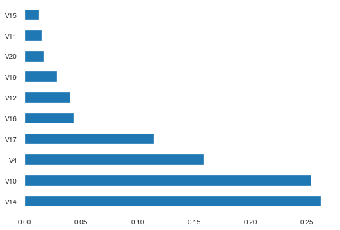

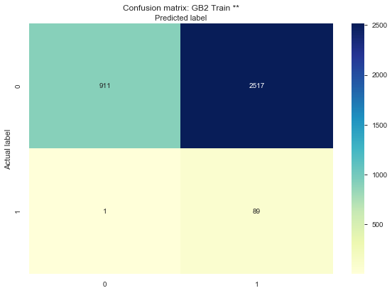

```
  No Skill : ROC AUC=0.500
GB2 Train ** : ROC AUC=0.978
```

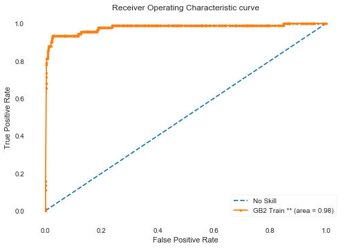

```
2 Step Final Confusion Matrix:
57192 2517
12 89
```

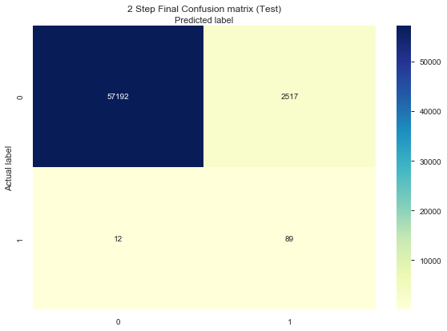

Now that we have built the 2 models from the test dataset, run the untouched validate dataset through both of them to get an unbiased result to compare against

```
0.9451488315842859
Accuracy score (training): 0.943
Accuracy score (validation): 0.945
AxesSubplot(0.125,0.125;0.775x0.755)
Confusion Matrix:
false positive pct: 5.477314399407014
tn  fp  fn  tp
24182 1404 2 45
[[24182  1404]
 [    2    45]]
Classification Report
              precision    recall  f1-score   support

           0       1.00      0.95      0.97     25586
           1       0.03      0.96      0.06        47

    accuracy                           0.95     25633
   macro avg       0.52      0.95      0.52     25633
weighted avg       1.00      0.95      0.97     25633

Specificity = 0.9451262409129993
Sensitivity = 0.9574468085106383
GB1 Validate **:TEST | AUC Score: 0.99
```

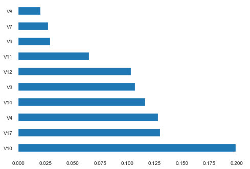

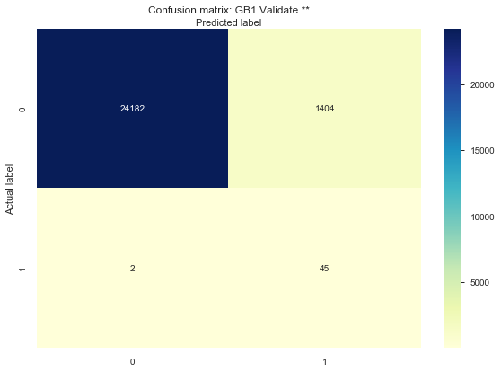

```
  No Skill : ROC AUC=0.500
GB1 Validate ** : ROC AUC=0.990
```

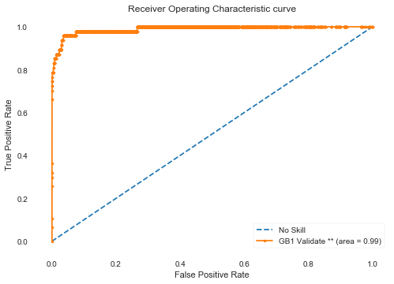

```
0.26570048309178745
Accuracy score (training): 0.969
Accuracy score (validation): 0.266
AxesSubplot(0.125,0.125;0.775x0.755)
Confusion Matrix:
false positive pct: 73.42995169082126
tn  fp  fn  tp
340 1064 0 45
[[ 340 1064]
 [   0   45]]
Classification Report
              precision    recall  f1-score   support

           0       1.00      0.24      0.39      1404
           1       0.04      1.00      0.08        45

    accuracy                           0.27      1449
   macro avg       0.52      0.62      0.23      1449
weighted avg       0.97      0.27      0.38      1449

Specificity = 0.24216524216524216
Sensitivity = 1.0
GB2 Validate **:TEST | AUC Score: 0.925
```

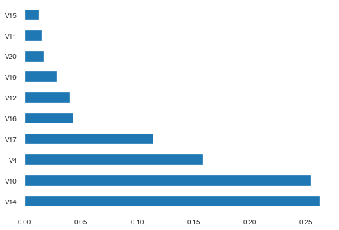

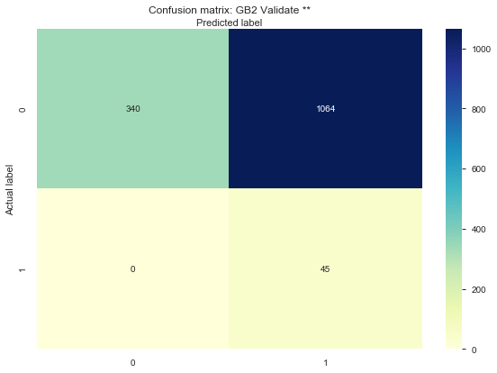

```
  No Skill : ROC AUC=0.500
GB2 Validate ** : ROC AUC=0.925
```

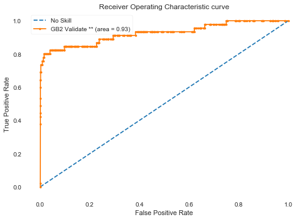

```
2 Step Final Confusion Matrix:
24522 1064
2 45
Specificity = 0.95841475807082
Sensitivity = 0.9574468085106383
2 Step Algorithm:TEST | AUC Score: 0.958
```

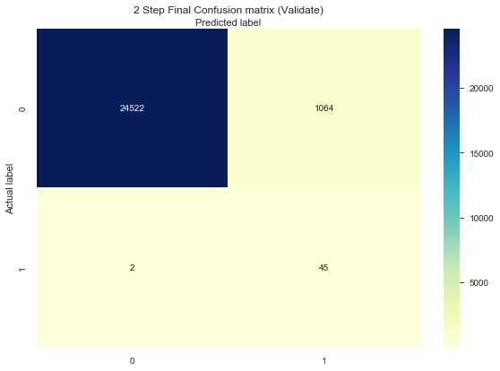

```
  No Skill : ROC AUC=0.500
    2-Step : ROC AUC=0.989
```

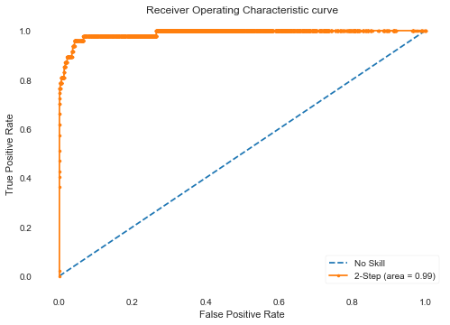

Next will try a few Neural Networks

Adding swish activation function code for possible use later, can compare to relu, etc

Create the models to be used layer, using Sequential()